# OHIBC: data_prep_spp.Rmd

*Compiled on Thu Oct 8 10:57:49 2015 by ohara*

# OHIBC Species Subgoal (Biodiversity)

This script prepares scores (status and trend) for species richness in British Columbia’s coastal regions. Spatial data from IUCN and Aquamaps is combined with extinction risk information from IUCN and conservation rank info based on NatureServe categories.

Currently, the Species Richness sub-goal model is identical to the OHI Global model: a region’s status is based upon an area-weighted average of species health across each BC reporting region.

From Halpern et al (2012):

> The target for the Species sub-goal is to have all species at a risk status of Least Concern. We scaled the lower end of the biodiversity goal to be 0 when 75% species are extinct, a level comparable to the five documented mass extinctions and would constitute a catastrophic loss of biodiversity. The Status of assessed species was calculated as the area- and threat status-weighted average of the number of threatened species within each 0.5 degree grid cell.

$Y_{cell} = \frac{\displaystyle\sum_{species}(Risk)}{n_{spp}}$

$Y_{SPP} = \frac{\displaystyle\sum_{cells}(Y_{cell} * A_{cell} * pA_{cell-rgn})}{A_{rgn}}$

$X_{SPP} = \frac{((1 - Y_{SPP}) - 0.25)}{(1 - 0.25)} * 100%$

where:

- $X_{SPP}$ is Species goal status
- $Y_{cell}$ is mean extinction risk for one cell
- $Y_{SPP}$ is area-weighted mean extinction risk for a region
- $A_{cell}$ is cell area
- $pA_{cell-rgn}$ is percent of cell area included in region
- *Risk* is scaled value for species extinction risk category, based on:
  - ‘LC’ = 0.0, ‘NT’ = 0.2, ‘VU’ = 0.4, ‘EN’ = 0.6, ‘CR’ = 0.8, ‘EX’ = 1.0
- SPP trend is calculated in a similar area-weighted mean, but population trend values are assigned according to:
  - ‘Decreasing’ = -0.5, ‘Stable’ = 0.0, ‘Increasing’ = +0.5

## Data sources

AquaMaps:

- From http://www.aquamaps.org/main/home.php: “AquaMaps are computer-generated predictions of natural occurrence of marine species, based on the environmental tolerance of a given species with respect to depth, salinity, temperature, primary productivity, and its association with sea ice or coastal areas.”
- Citation: Kaschner, K., J. Rius-Barile, K. Kesner-Reyes, C.Garilao, S.O. Kullander, T. Rees and R. Froese (2013). AquaMaps: Predicted range maps for aquatic species. World wide web electronic publication, www.aquamaps.org, Version 08/2013.

IUCN Red List spatial data: species range map shapefiles

- Species range map shapefiles downloaded from: http://www.iucnredlist.org/technical-documents/spatial-data
- Citation: IUCN 2014. The IUCN Red List of Threatened Species. Version 2014.1. http://www.iucnredlist.org. Downloaded on 21 September 2015.

IUCN Red List species index: list of all IUCN red list species, incl IUCN species ID and extinction risk category

- Extinction risk categories downloaded from: http://api.iucnredlist.org/index/all.csv
- Habitat and subpopulation information, by species, scraped from: http://www.iucnredlist.org/details//0
- Citation: IUCN 2015. The IUCN Red List of Threatened Species. Version 2015-3. http://www.iucnredlist.org. Downloaded on 9 September 2015.

NatureServe/BC CDC conservation rank info from BC Species and Ecosystems Explorer:

- BC Conservation Data Centre: http://www.env.gov.bc.ca/atrisk/toolintro.html
- NatureServe conservation status: http://explorer.natureserve.org/ranking.htm#global
- Citation: B.C. Conservation Data Centre. 2013. BC Species and Ecosystems Explorer. B.C. Ministry of Environment, Victoria B.C. Available: http://a100.gov.bc.ca/pub/eswp/. Downloaded on 3 August 2015.

## Load species lookup table

Currently this uses the global species lookup table. How this list is generated (file locations are in `~/github/ohiprep/globalprep/SPP_ICO`):

- in `ingest_iucn.R`:
  - Pull full IUCN list from http://api.iucnredlist.org/index/all.csv
  - Filter the list to marine species as indicated on each species page
  - Standardize old extinction risk categories
  - Append population trend and parent/subpop info from species web pages
  - Write to `spp_iucn_mar.csv` in git-annex.
- in `spp_fxn.R::create_spp_master_lookup()`:
  - Pull in Aquamaps species information table, create sciname field and standardize categories
  - Pull in IUCN marine species info from `ingest_iucn.R`
  - `full_join()` the two species lists
  - Determine overall category, trend, and spatial info source (preferring IUCN)
  - Remove duplicate records and data-deficient records
  - Convert text extinction risk category and popn trends to number values
  - Identify parent/subpopulations and aliases within `spatial_source` field.
- *File `/Volumes/data_edit/git-annex/globalprep/SPP_ICO/v2015/intermediate/spp_all.csv`: git commit info unavailable. Not version-controlled in Git?*

Variables in `spp_all`: am_sid | sciname | am_category | iucn_sid | iucn_category | popn_trend | parent_sid | subpop_sid | popn_category | info_source | spp_group | id_no | spatial_source | category_score | trend_score

Selection of rows and columns:

| sciname | am_sid | iucn_sid | popn_trend | popn_category | spatial_source |
| --- | --- | --- | --- | --- | --- |
| Thymops birsteini | ITS-552925 | 170038 | Unknown | LC | iucn |
| Limulus polyphemus | URM-M-1454 | 11987 | NA | NT | am |
| Auriculastra subula | AFD-Pul-494 | 184918 | Unknown | LC | am |
| Conus stearnsii | ITS-567398 | 192532 | Unknown | VU | iucn |
| Neritina virginea | ITS-70162 | 189436 | Stable | LC | am |
| Conus vexillum | ITS-656358 | 192778 | Unknown | LC | iucn |

## Append BC-specific species risk assessment codes

Data downloaded from BC Species and Ecosystems Explorer includes information on global status and provincial status for species, as assessed by NatureServe.

```r
spp_all <- spp_append_bcsee(spp_all)

### for this iteration: overwrite IUCN global scores with BCSEE provincial scores.
spp_all_bcsee <- spp_all %>%
  mutate(category_score = ifelse(!is.na(status_pr_score), status_pr_score, category_score))

### for this iteration: overwrite IUCN global scores with BCSEE provincial
### scores (preferred) or global (second choice).
# spp_all_bcsee <- spp_all %>%
#   mutate(category_score = ifelse(!is.na(status_gl_score), status_gl_score, category_score),
#          category_score = ifelse(!is.na(status_pr_score), status_pr_score, category_score))
```

## Define assessment regions

Using OHIBC region polygons, determine 0.5° raster cells corresponding to each region.

```
## Reading OHIBC regions shapefile...
##   ~/github/ohibc/regions/ohibc_rgn_wgs84.shp
```

```
## Reading loiczid cell proportions by region from:
##   ~/github/ohibc/spp_ico/v2016/int/cell_id_by_rgn.csv
```

- *File `~/github/ohibc/regions/ohibc_rgn_wgs84.shp`: most recent commit info: commit 43ad53709c74ebbe2f3a2843b6099620f3062a67 Author: Casey O’Hara ohara@nceas.ucsb.edu Date: Tue Sep 29 12:18:24 2015 -0700*

### Map of region ID per cell

*Note that `subs()` can’t deal with duplicate cell IDs; for cells included in two or more regions get the minimum region ID value*

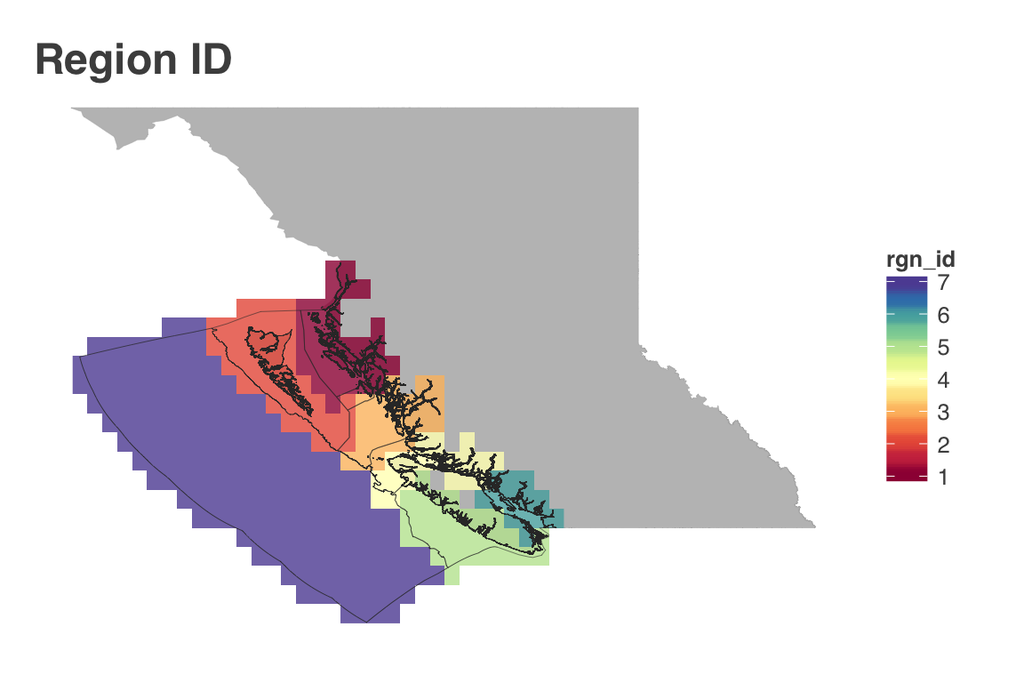

## Generate species per cell tables for Aquamaps and IUCN

These species-per-cell tables are generated from global SPP goal data, from AquaMaps data and IUCN range maps, filtered to just OHIBC regions.

```
## Reading Aquamaps species per cell file from:
##   ~/github/ohibc/spp_ico/v2016/int/am_cells_spp_prob0.csv
```

```
## Cell-by-cell summary for Aquamaps species already exists.  Reading from:
##   ~/github/ohibc/spp_ico/v2016/summary/spp_sum_am_cells.csv
```

```
## Generating cell-by-cell summary for Aquamaps species.
## Number of Aquamaps species: 2027
## Grouping by cell and summarizing by mean category, mean trend, and n_spp for each, for AM spatial info.
## Writing cell-by-cell summary for Aquamaps species to:
##   ~/github/ohibc/spp_ico/v2016/summary/spp_sum_am_cellsbcsee.csv
```

Aquamaps cell summary: quick check (head)

| loiczid | mean_cat_score | mean_popn_trend_score | n_cat_species | n_trend_species | source |
| --- | --- | --- | --- | --- | --- |
| 49060 | 0.135484 | -0.142857 | 62 | 49 | aquamaps |
| 49061 | 0.130303 | -0.147059 | 66 | 51 | aquamaps |
| 49780 | 0.124561 | -0.152174 | 114 | 69 | aquamaps |
| 49781 | 0.133962 | -0.149254 | 106 | 67 | aquamaps |
| 50494 | 0.106667 | -0.145833 | 135 | 72 | aquamaps |
| 50495 | 0.104688 | -0.130435 | 128 | 69 | aquamaps |

```
## Cell-by-cell summary for IUCN species already exists.  Reading from:
##   ~/github/ohibc/spp_ico/v2016/summary/spp_sum_iucn_cells.csv
```

```
## Generating cell-by-cell summary for IUCN range-map species.
## Writing cell-by-cell summary for IUCN species to:
##   ~/github/ohibc/spp_ico/v2016/summary/spp_sum_iucn_cellsbcsee.csv
```

IUCN cell summary: quick check (head)

| loiczid | mean_cat_score | mean_popn_trend_score | n_cat_species | n_trend_species | source |
| --- | --- | --- | --- | --- | --- |
| 49060 | 0.200000 | 0 | 34 | 23 | iucn |
| 49061 | 0.200000 | 0 | 34 | 23 | iucn |
| 49780 | 0.200000 | 0 | 34 | 23 | iucn |
| 49781 | 0.200000 | 0 | 34 | 23 | iucn |
| 49782 | 0.200000 | 0 | 34 | 23 | iucn |
| 50494 | 0.206061 | 0 | 33 | 22 | iucn |

### Map of species count by cell

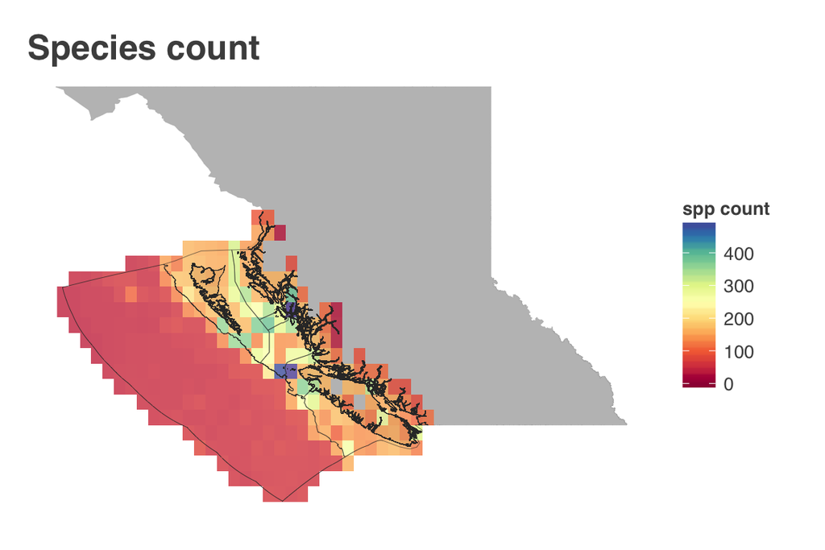

## Summarize mean category/trend per cell/region, IUCN

For each raster cell, we generate a summary of number of species included, average extinction risk score of all species in cell, and average trend score of all species in cell with population trend information. This section calculates extinction risk score based solely on IUCN category ranks, which excludes subpopulation scores due to lack of spatially explicit distribution info for subpopulations.

From raster-level summaries, we generate a region-level summary based on area-weighted average extinction risk and population trend.

```
## Writing summary file of area-weighted mean category & trend per region:
##   ~/github/ohibc/spp_ico/v2016/summary/rgn_summary.csv
```

summary by LOICZID (head)

| loiczid | weighted_mean_cat | weighted_mean_trend |
| --- | --- | --- |
| 49060 | 0.1583334 | -0.0972221 |
| 49061 | 0.1540000 | -0.1013515 |
| 49780 | 0.1418916 | -0.1141305 |
| 49781 | 0.1499998 | -0.1111113 |
| 49782 | 0.2000000 | 0.0000000 |
| 50494 | 0.1261908 | -0.1117019 |

summary by region (head)

| rgn_id | rgn_mean_cat | rgn_mean_trend | status |
| --- | --- | --- | --- |
| 1 | 0.1360456 | -0.1146363 | 81.86058 |
| 2 | 0.1370014 | -0.1026346 | 81.73314 |
| 3 | 0.1414740 | -0.1006650 | 81.13680 |
| 4 | 0.1367157 | -0.1063329 | 81.77123 |
| 5 | 0.1485512 | -0.0986942 | 80.19317 |
| 6 | 0.1463137 | -0.0905617 | 80.49150 |

## Summarize mean category/trend per cell/region, IUCN & BCSEE

This section performs similar calculations, but here calculates extinction risk score based on NatureServe province-level rankings where available, and IUCN category ranks elsewhere. IUCN ranks exclude subpopulation scores due to lack of spatially explicit distribution info for subpopulations.

```
## Writing summary file of area-weighted mean category & trend per region:
##   ~/github/ohibc/spp_ico/v2016/summary/rgn_summary.csv
```

summary by LOICZID (head)

| loiczid | weighted_mean_cat | weighted_mean_trend |
| --- | --- | --- |
| 49060 | 0.2296703 | -0.0895522 |
| 49061 | 0.2273684 | -0.0942029 |
| 49780 | 0.1957447 | -0.1117647 |
| 49781 | 0.2045113 | -0.1084337 |
| 49782 | 0.2705882 | 0.0000000 |
| 50494 | 0.1770186 | -0.1091954 |

summary by region (head)

| rgn_id | rgn_mean_cat | rgn_mean_trend | status |
| --- | --- | --- | --- |
| 1 | 0.1873319 | -0.1121728 | 75.02241 |
| 2 | 0.1799482 | -0.1001214 | 76.00690 |
| 3 | 0.1816805 | -0.0963604 | 75.77593 |
| 4 | 0.1806244 | -0.1043138 | 75.91675 |
| 5 | 0.1875403 | -0.0961520 | 74.99463 |
| 6 | 0.1979162 | -0.0861835 | 73.61117 |

### Map of mean extinction risk category value by cell

*Category value range: least concern = 0, extinct = 1*

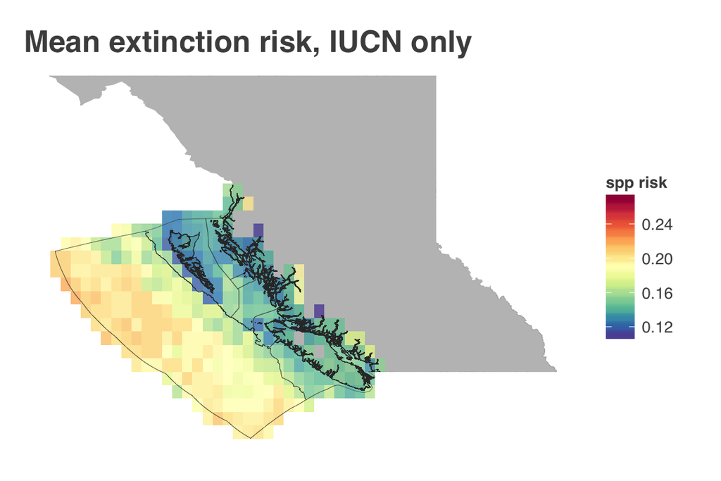

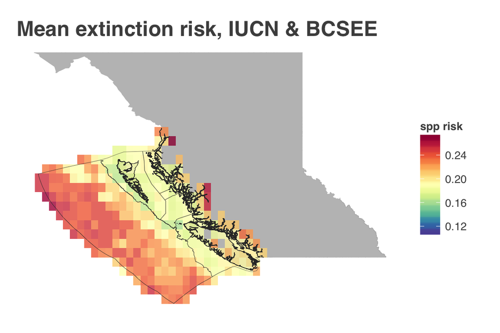

## Create final output files

From the region-level summaries of extinction risk and population trend, we calculate regional status and trend scores.

```
## Writing SPP status and trend based only on IUCN categories to:
##   ~/github/ohibc/spp_ico/v2016/data/spp_status.csv
##   ~/github/ohibc/spp_ico/v2016/data/spp_trend.csv
```

```
## Writing SPP status and trend based on IUCN & BCSEE categories to:
##   ~/github/ohibc/spp_ico/v2016/data/spp_status_bcsee.csv
##   ~/github/ohibc/spp_ico/v2016/data/spp_trend_bcsee.csv
```

### Compare scores from IUCN only vs IUCN & BCSEE

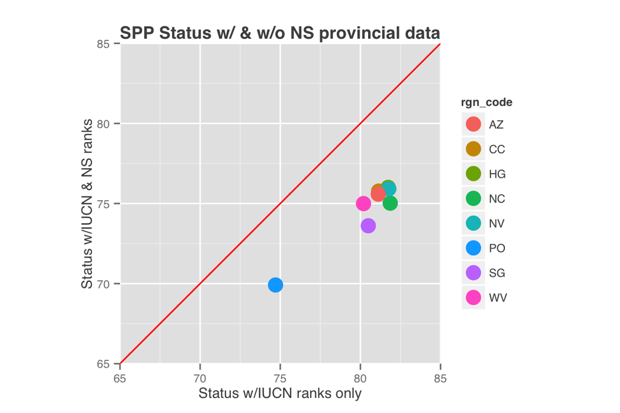

## Plot map of status by region

While the table shows status for both iterations (IUCN rankings only and IUCN + NatureServe rankings), the status plot shows only the BC-specific version (IUCN + NatureServe rankings). Currently no trend information is taken from NatureServe, so trend is based entirely on IUCN rankings.

SPP Status by region, IUCN & NatureServe rankings:

| rgn_id | iucn_score | bcsee_score | rgn_name | rgn_code | area_km2 | area_hec |
| --- | --- | --- | --- | --- | --- | --- |
| 1 | 81.86058 | 75.02241 | North Coast | NC | 17519.937 | 1751993.7 |
| 2 | 81.73314 | 76.00690 | Haida Gwaii | HG | 46053.741 | 4605374.1 |
| 3 | 81.13680 | 75.77593 | Central Coast | CC | 20517.013 | 2051701.3 |
| 4 | 81.77123 | 75.91675 | North Vancouver Island | NV | 13731.589 | 1373158.9 |
| 5 | 80.19317 | 74.99463 | West Vancouver Island | WV | 28162.407 | 2816240.7 |
| 6 | 80.49150 | 73.61117 | Strait of Georgia | SG | 8159.221 | 815922.1 |
| 7 | 74.70453 | 69.91309 | Pacific Offshore | PO | 315888.121 | 31588812.1 |
| 8 | 81.11527 | 75.58305 | Aristazabal Island | AZ | 3210.948 | 321094.8 |

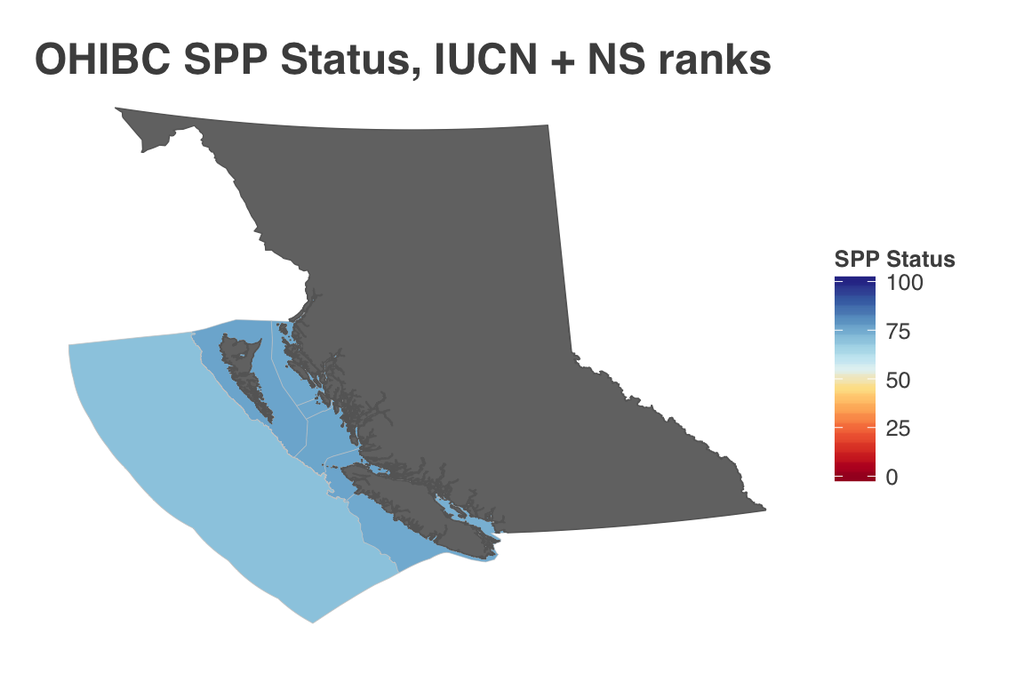

SPP Trend by region:

| rgn_id | score | rgn_name | rgn_code | area_km2 | area_hec |
| --- | --- | --- | --- | --- | --- |
| 1 | -0.1146363 | North Coast | NC | 17519.937 | 1751993.7 |
| 2 | -0.1026346 | Haida Gwaii | HG | 46053.741 | 4605374.1 |
| 3 | -0.1006650 | Central Coast | CC | 20517.013 | 2051701.3 |
| 4 | -0.1063329 | North Vancouver Island | NV | 13731.589 | 1373158.9 |
| 5 | -0.0986942 | West Vancouver Island | WV | 28162.407 | 2816240.7 |
| 6 | -0.0905617 | Strait of Georgia | SG | 8159.221 | 815922.1 |
| 7 | -0.1194893 | Pacific Offshore | PO | 315888.121 | 31588812.1 |
| 8 | -0.1081377 | Aristazabal Island | AZ | 3210.948 | 321094.8 |

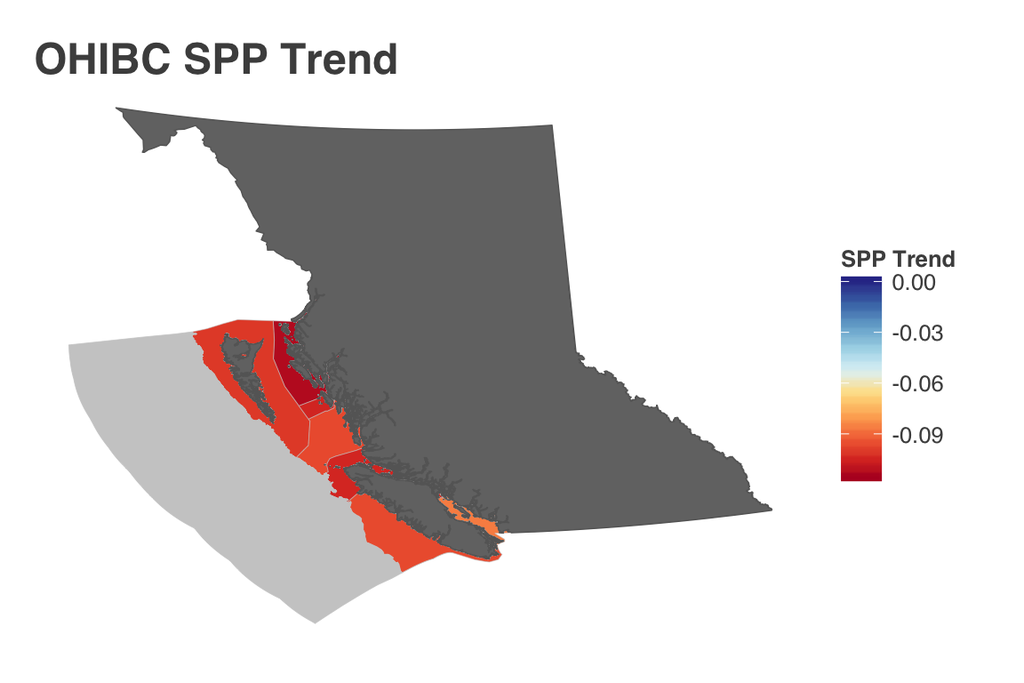

## Summarize mean category/trend within 3 nm of shore

Create final outputs for 3nm zone for resilience calculations

```
## Reading OHIBC 3nm offshore regions shapefile...
##   ~/github/ohibc/regions/ohibc_offshore_3nm_wgs84.shp
```

- *File `~/github/ohibc/regions/ohibc_offshore_3nm_wgs84.shp`: most recent commit info: commit 43ad53709c74ebbe2f3a2843b6099620f3062a67 Author: Casey O’Hara ohara@nceas.ucsb.edu Date: Tue Sep 29 12:18:24 2015 -0700*

```
## Writing loiczid/csq/cell proportions/cell areas by region to:
##   ~/github/ohibc/spp_ico/v2016/int/cell_id_by_rgn_3nm.csv
```

```
## Writing summary file of area-weighted mean category & trend per region:
##   ~/github/ohibc/spp_ico/v2016/summary/rgn_summary_3nm.csv
```

```
## Writing SPP status and trend for 3nm regions to:
##   ~/github/ohibc/spp_ico/v2016/data/spp_status_3nm.csv
##   ~/github/ohibc/spp_ico/v2016/data/spp_trend_3nm.csv
```

# Provenance

- *Run ID:*
  - *3*
- *System info:*
  - *System: Darwin, Release: 14.5.0. Machine: x86_64. User: ohara.*
- *Session info:*
  - *R version: R version 3.2.2 (2015-08-14), Platform: x86_64-apple-darwin13.4.0, Running under: OS X 10.10.5 (Yosemite).* * *
- *Git commit info:*
  - *File `~/github/ohibc/spp_ico/data_prep_spp.Rmd`: most recent commit info: commit 5a8c37c7f407578ae5d8d81f1a5ba2fab0a92817 Author: Casey O’Hara ohara@nceas.ucsb.edu Date: Tue Oct 6 15:41:29 2015 -0700*

Provenance summary for this run:

| run_id | run_date | file | type | commit_url | commit_author | commit_date |
| --- | --- | --- | --- | --- | --- | --- |
| 3 | Thu Oct 8 11:08:08 2015 | /Volumes/data_edit/git-annex/globalprep/SPP_ICO/v2015/intermediate/spp_all.csv | input | no version control info found | NA | NA |
| 3 | Thu Oct 8 11:08:08 2015 | ~/github/ohibc/spp_ico/v2016/int/cell_id_by_rgn.csv | input | https://github.com/OHI-Science/ohibc/commit/4dae997af003ad8b9701be554548be19c68460f5 | Casey O’Hara ohara@nceas.ucsb.edu | Wed Sep 30 10:22:10 2015 -0700 |
| 3 | Thu Oct 8 11:08:08 2015 | ~/github/ohibc/regions/ohibc_rgn_wgs84.shp | input | https://github.com/OHI-Science/ohibc/commit/43ad53709c74ebbe2f3a2843b6099620f3062a67 | Casey O’Hara ohara@nceas.ucsb.edu | Tue Sep 29 12:18:24 2015 -0700 |
| 3 | Thu Oct 8 11:08:08 2015 | ~/github/ohibc/spp_ico/v2016/int/am_cells_spp_prob0.csv | input | https://github.com/OHI-Science/ohibc/commit/43ad53709c74ebbe2f3a2843b6099620f3062a67 | Casey O’Hara ohara@nceas.ucsb.edu | Tue Sep 29 12:18:24 2015 -0700 |
| 3 | Thu Oct 8 11:08:08 2015 | ~/github/ohibc/spp_ico/v2016/summary/spp_sum_am_cells.csv | input | https://github.com/OHI-Science/ohibc/commit/43ad53709c74ebbe2f3a2843b6099620f3062a67 | Casey O’Hara ohara@nceas.ucsb.edu | Tue Sep 29 12:18:24 2015 -0700 |
| 3 | Thu Oct 8 11:08:08 2015 | ~/github/ohibc/spp_ico/v2016/summary/spp_sum_iucn_cells.csv | input | https://github.com/OHI-Science/ohibc/commit/43ad53709c74ebbe2f3a2843b6099620f3062a67 | Casey O’Hara ohara@nceas.ucsb.edu | Tue Sep 29 12:18:24 2015 -0700 |
| 3 | Thu Oct 8 11:08:08 2015 | ~/github/ohibc/regions/ohibc_offshore_3nm_wgs84.shp | input | https://github.com/OHI-Science/ohibc/commit/43ad53709c74ebbe2f3a2843b6099620f3062a67 | Casey O’Hara ohara@nceas.ucsb.edu | Tue Sep 29 12:18:24 2015 -0700 |
| 3 | Thu Oct 8 11:08:08 2015 | /Volumes/data_edit/git-annex/globalprep/_raw_data/aquamaps/v2014/tables/hcaf.csv | input | no version control info found | NA | NA |
| 3 | Thu Oct 8 11:08:08 2015 | ~/github/ohibc/spp_ico/data_prep_spp.Rmd | script | https://github.com/OHI-Science/ohibc/commit/5a8c37c7f407578ae5d8d81f1a5ba2fab0a92817 | Casey O’Hara ohara@nceas.ucsb.edu | Tue Oct 6 15:41:29 2015 -0700 |